# Clustering Evangelicals

Ryan Burge

April 27, 2016

```r
library(ggplot2)
library(foreign)
library(car)
library(dplyr)
library(rpart)
library(fpc)
library(ggplot2)
library(Rmisc)
library(extrafont)
library(extrafontdb)
```

# Are evangelicals are a monolith?

A lot of outsiders have begun to wonder if evangelicals are truly a monolithic bloc or are there some cracks beginning to form in what we believe an evangelical to be. I wanted to take a look at that by using a technique that is helps to sort a group into similar cases, also known as a cluster. These clusters are created using an algorithm and will help to divide evangelicals up into camps.

## Data Cleaning

```r
gss <- read.dta("D:/reltrad.dta", convert.factors = FALSE)
gss <- subset(gss, year >= 2010)
evan <-subset(gss, evangelical == 1)
```

The first thing I have done is used the RELTRAD coding scheme employed by Steensland et al (2000) to create a unified measure of evangelicalism. Here is a link to my github with that syntax for both [Stata and R:](https://github.com/ryanburge/reltrad). In addition I am just using data from the General Social Survey from 2010 to 2014. That is the three most recent waves of the GSS. The subgroup of evangelicals is sufficiently large (about 1500). I am going to do a bunch of cleaning behind the scenes now to get the data in a usable format. To see the full coding and cleaning syntax I have posted it [here.](https://github.com/ryanburge/clustering/blob/master/datacleaning)

I’m going to create a dataframe to just do the clustering, called test. Here’s the variables that are included.

```r
test <- select(evan, age, literal, attnd, male, tolerance, abortion, gaymarriage, gaysex, repubid, welfare, military, environment, drugs, educ)
```

I can’t have any missing data for the clustering to work properly. I have a handful of cases where age is missing, as well as education. I am going to use some prediction modeling to make a guess at both the age and education for the missing values.

```r
age_fit <- rpart(age ~ educ + attnd + male + tolerance + abortion + gaymarriage + gaysex + repubid + welfare + military + environment + drugs, data = test[!is.na(test$age), ],
method = 'anova')
test$age[is.na(test$age)] <- predict(age_fit, test[is.na(test$age), ])

educ_fit <- rpart(educ ~ age + attnd + male + tolerance + abortion + gaymarriage + gaysex + repubid + welfare + military + environment + drugs, data = test[!is.na(test$age), ],
method = 'anova')
test$educ[is.na(test$educ)] <- predict(educ_fit, test[is.na(test$educ), ])
```

## Clustering

Now, it’s time to run the clustering. But how many clusters should I use?

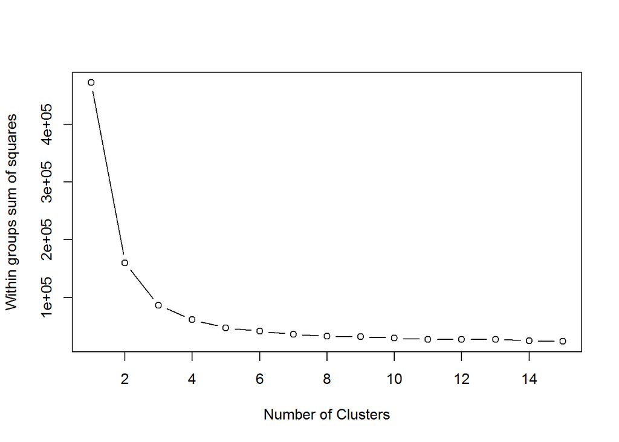

```r
set.seed(555)
wss <- (nrow(test)-1)*sum(apply(test,2,var))
for (i in 2:15) wss[i] <- sum(kmeans(test,
                                     centers=i,iter.max=1000,algorithm="MacQueen")$withinss)

plot(1:15, wss, type="b", xlab="Number of Clusters",
     ylab="Within groups sum of squares")
```

Using the graph it becomes apparent that the jump from 2 to 3 clusters still gives us a good deal of utility, but that moving to four clusters gives us a lot less. Let’s stick to three.

```r
k<-kmeans(test, centers=3,iter.max=1000,algorithm="MacQueen")
k$size
```

```
## [1] 597 557 418
```

```r
k$centers
```

```
##        age   literal     attnd      male tolerance  abortion gaymarriage
## 1 51.70015 0.5979899 0.6155779 0.4237856 0.4108319 0.1825796  0.06365159
## 2 31.68223 0.5385996 0.6429533 0.3788151 0.4240575 0.1579892  0.09694794
## 3 71.72727 0.6028708 0.6420455 0.4043062 0.3360447 0.1315789  0.03588517
##       gaysex  repubid   welfare  military environment     drugs     educ
## 1 0.11055276 4.216080 0.4003350 0.2881072   0.3763261 0.4103853 13.10720
## 2 0.15978456 4.168761 0.3776182 0.2998205   0.3997606 0.4111311 13.39677
## 3 0.07655502 4.270335 0.3915470 0.2838915   0.3197767 0.3979266 12.47060
```

Before I go on, I have to note something. I know that in a typical clustering scenario you would want to standardize all your variables into a singular range, typically 0-1. However, this exercise was really meant to assess three generations of evangelicals and note the changes between those generations. Because of that the clustering is basically being swamped by the age variable.

Let’s visualize those three age clusters.

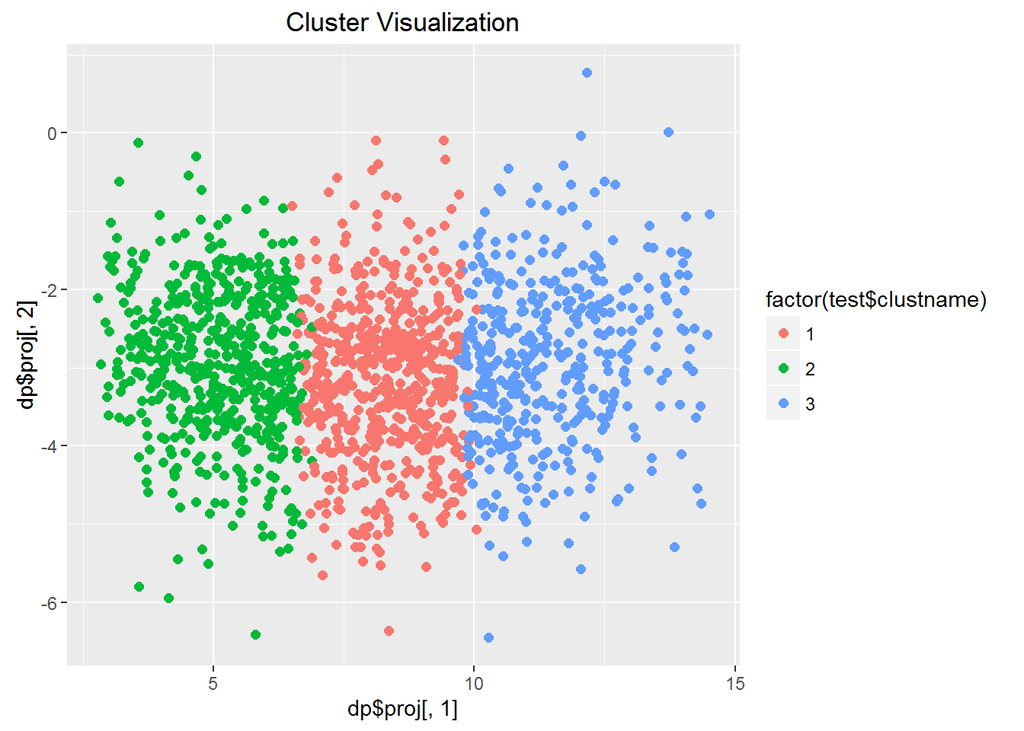

```r
dp = discrproj(test, k$cluster)
test$clustname<-k$cluster
test$clustname<-factor(test$clustname)
ggplot(test, aes(dp$proj[,1], dp$proj[,2], color=factor(test$clustname)))+geom_point(pch=19,size=2)+ggtitle("Cluster Visualization")
```

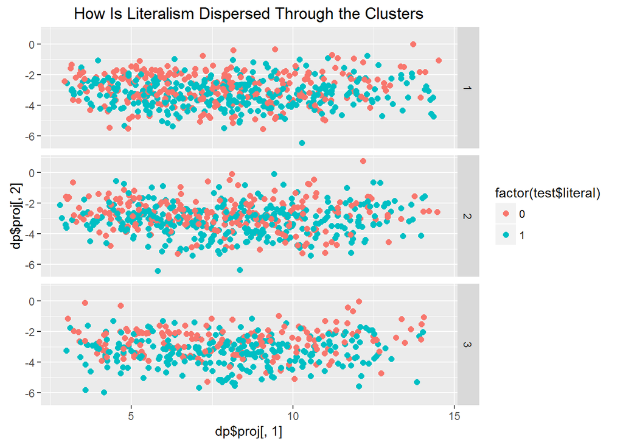

```r
ggplot(test, aes(dp$proj[,1], dp$proj[,2], color=factor(test$literal)))+geom_point(pch=19,size=2)+facet_grid(clustname~.)+ggtitle("How Is Literalism Dispersed Through the Clusters")
```

These visuals do look really nice, but because I am clustering on so many factors a two dimensional plot doesn’t really convey how the clusters actually look. We can tell that they are logically distributed across the x axis, however.

## Results

Let’s start visualizing our results. I want to be able to tell two things.

1. Are evangelicals alike? Do each of the three clusters have the same opinions on government? Church attendance? The Bible?
2. How different are evangelicals than the general population?

**Here’s how to read the charts. A dot represents the mean for each group. The lines extending out each side of the dot are the 84%* confidence intervals. If the lines for a cluster overlap the lines for another cluster then we cannot say that they have statistically different opinions on the subject.**

*The 84% confidence interval for comparing means has become the standard measure for this application. While in other instances we rely on 95% CIs, recent writing in statistical theory have concluded that the 95% threshold is much too conservative. To read more [click here.](http://www.ncbi.nlm.nih.gov/pmc/articles/PMC524673/)

**The vertical dashed line you will see in the following graphs represents the mean of the entire GSS sample, not just evangelicals.**

### Religious Behavior

Let’s take a look at two religious behaviors. Believing in a literal Bible and church attendance.

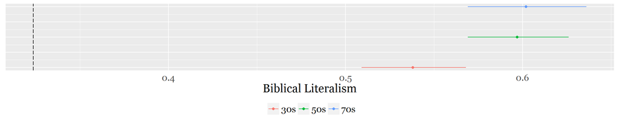

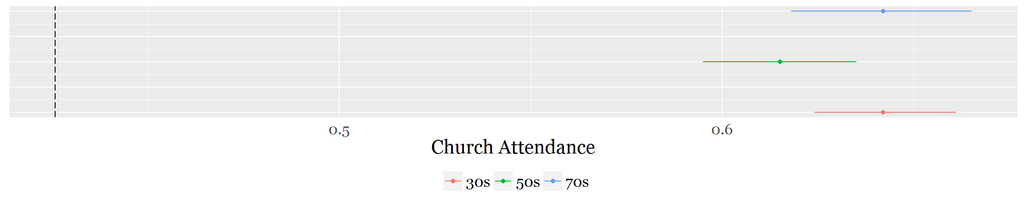

There are no surprises here. Evangelicals are much more likely to believe in a literal Bible and although the youngest cluster in the analysis is less likely to belive that the Bible is literally true, each of the clusters is not statistically distinct. The same is true of church attendance. No matter the age, evangelicals attend church at basically the same rate. Which is much more frequently than the general populace.

### Tolerance

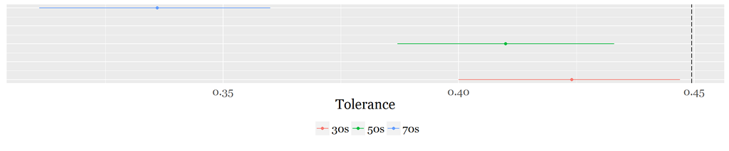

### Social Issues

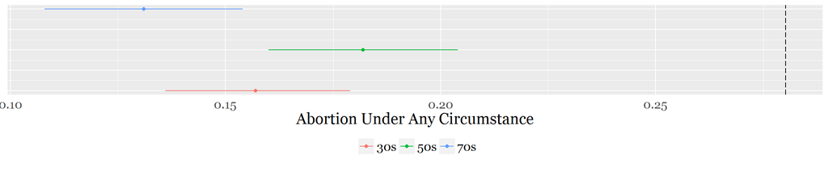

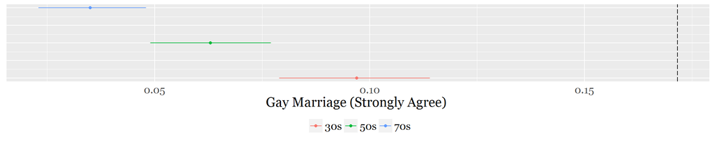

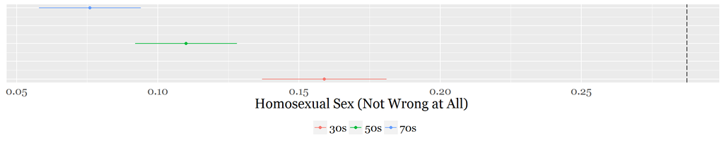

### Party Affiliation

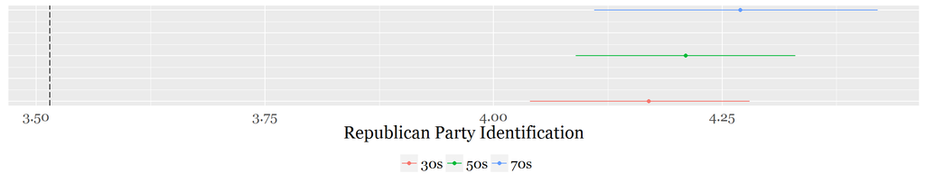

### Spending Issues

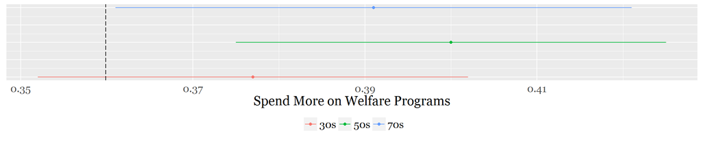

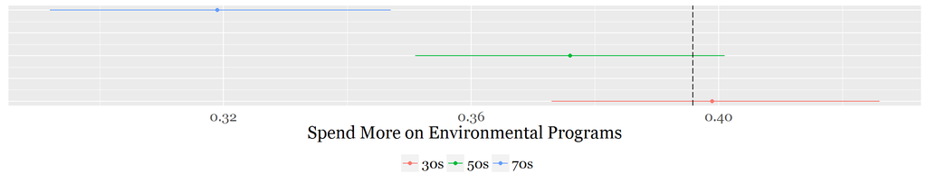

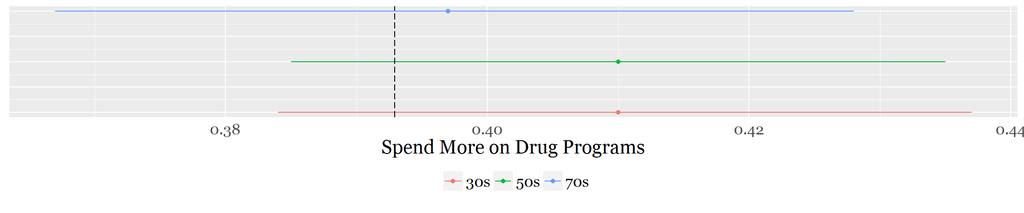

## Concluding Thoughts

I had to supress a lot of syntax to make this more readable. For full coding syntax visit my [Github page](https://github.com/ryanburge/clustering)